# Senior Mathematics Project

## Statistical Analysis of Global Warming and Greenhouse Gases

### By Eduardo Martinez

## Introduction

## Global Warming Background (EPA)

- Earth absorbs energy from the sun and emits some back as heat
- This exchange of energy determines Earth’s temperature
- Exchange is typically stable
- If unstable, there will be a heating or cooling effect

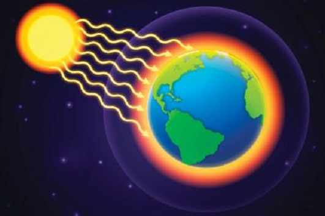

## The Greenhouse Effect (EPA)

- Radiating forces
- Greenhouse gases (GHGs) are positive radiating forces
- GHGs can persist for a long time
- Humans have caused an increase in GHG concentration
- Carbon Dioxide (CO2), Nitrous Oxide (N2O), and Methane (CH4)

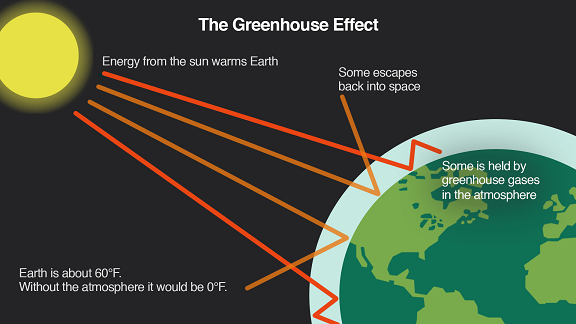

## Consequences of Global Warming (IPCC)

- Ecological, physical and health consequences
  - Extreme weather (e.g., floods, storms, heatwaves, and droughts)
  - Rising sea-levels
  - Constrained crop growth
- If average global temperatures increased by **2.0°C**:
  - 37% will experience severe heatwaves at least once every 5 years
  - 70+% of coastline sea-level will rise by >0.66 feet (0.2 meters)
  - Coral reefs will become virtually non-existent
  - 18% of insects, 8% of vertebrates, and 16% of plants will lose >50% of their geographical range

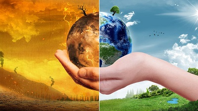

## Study Background

## Emissions Data

- CO2 Emissions (1955-2017) in 100 million tonnes per year
  - Measures annual territorial emissions from fossil fuels and cement
  - Source: Global Carbon Project & Carbon Dioxide Information Analysis Centre (CDIAC)
- CH4 and N2O Emissions (1970-2012) in 100 million tonnes of carbon dioxide equivalents (tCO₂e)
  - CH4 measures emissions from human activities such as agriculture and from industrial production
  - N2O emissions from agricultural biomass burning, industrial activities, and livestock
  - Source: Emission Database for Global Atmospheric Research (EDGAR)

## Atmospheric Concentration Data

- CO2 Global Annual Average Atmospheric Concentration (1880-2018)
  - Measured in parts per million (ppm).
  - Source: The NOAA Earth System Research Laboratories (ESRL)
- CH4 Global Annual Average Atmospheric Concentration (1880-2018)
  - Measured in parts per billion (ppb).
  - Source: EEA & NOAA
- Nitrous Oxide (N2O) Average Atmospheric Concentration (1880-2016)
  - Measured in parts per billion (ppb).
  - Source: European Environment Agency’s (EEA) Advanced Global Atmospheric Gases Experiment (AGAGE)
- \(1\ ppm = 1,000\ ppb\)

## Temperature Data

- Land-Ocean Temperature (°C) (1880-2019)
  - Calculated via anomally data that used a baseline temperature of 13.9, which was the average from 1901-2000
  - Source: National Oceanic and Atmospheric Administration (NOAA)

[figure not shown]

## Methods

- Linear Regression Modeling using R Programming Language (RStudio)
- Research Questions:
  - How have gas emissions, concentration, temperatures, and the population changed over time?
  - Are gas emissions, concentrations, and the population related to temperature?
  - Will global temperatures increase in the future? If so, by how much

## How to Interpret Linear Regression Results:

- Equation of the Regression Line: \(y = a + bX\)
  - \(y\) = estimated value of DV, \(a\) = y-intercept, \(b\) = slope, and \(X\) = value on the IV.
- 95% Prediction Interval: \(\hat{y} - E < y < \hat{y} + E\)
- Coefficient of Determinism: \(R^{2} = \frac{explained\ variation}{total\ variation}\)
  - Values range from 0 to 1
- \(p\)-\(value\)
  - I used a \(0.05\) significance level.
  - \(p < 0.05\) suggests there is a linear correlation.
  - The majority models were significant

## Results

## Temperature VS Year By Gas Concentrations (1880-2019)

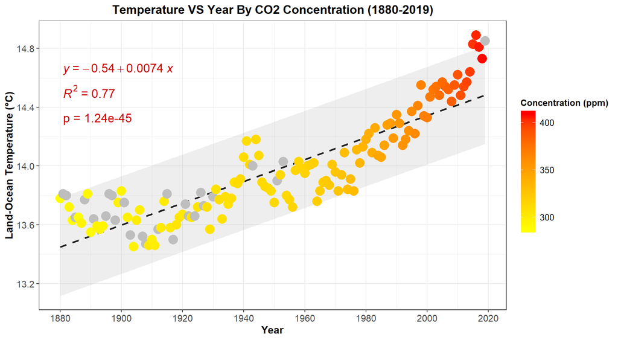

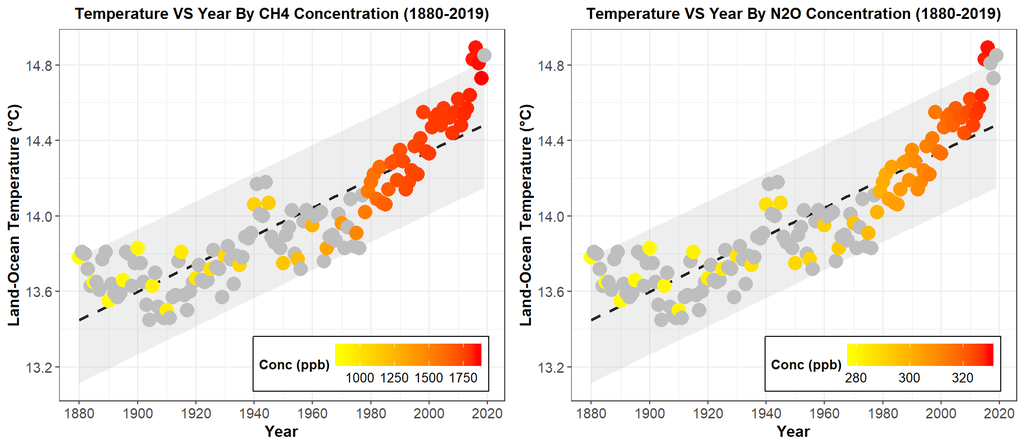

## Concentrations

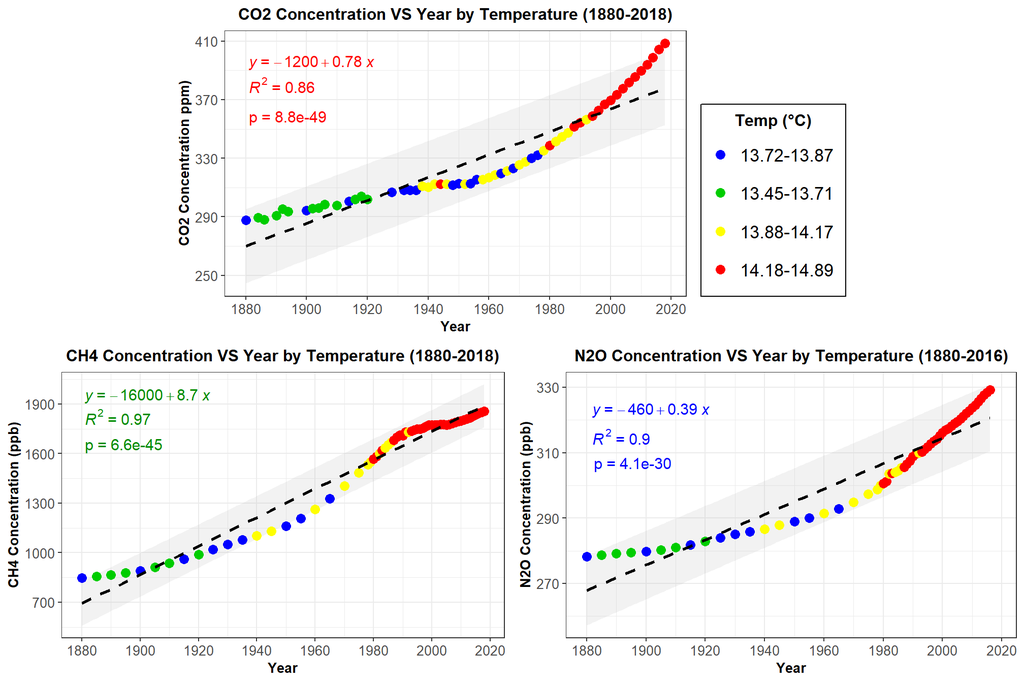

## Population VS Year

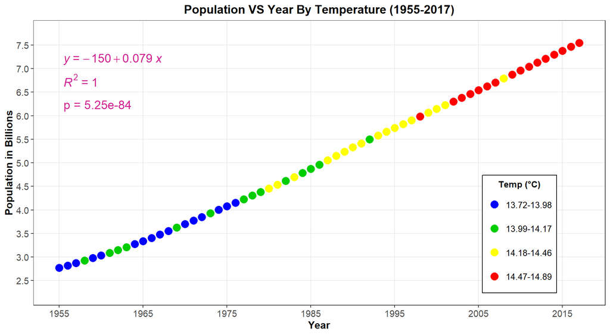

## Emissions

```r
co2emissyearlm <- lm(CO2_Emissions ~ Year, data = dfworld, na.action = na.exclude)
co2emissyearpreds <- as_tibble(predict(co2emissyearlm, newdata=yearintw, interval="predict", level=0.95)) %>%
  mutate(Year = yearintw$Year) %>%
  select(Year, everything())

ch4emissyearlm <- lm(CH4_Emissions ~ Year, data = dfworld2, na.action = na.exclude)
ch4emissyearpreds <- as_tibble(predict(ch4emissyearlm, newdata=yearintw2, interval="predict", level=0.95)) %>%
  mutate(Year = yearintw2$Year) %>%
  select(Year, everything())

n2oemissyearlm <- lm(N2O_Emissions ~ Year, data = dfworld2, na.action = na.exclude)
n2oemissyearpreds <- as_tibble(predict(n2oemissyearlm, newdata=yearintw2, interval="predict", level=0.95)) %>%
  mutate(Year = yearintw2$Year) %>%
  select(Year, everything())
```

```r
CO2emissionsyear_plot <- dfworld %>%
  ggplot(aes(x = Year, y = CO2_Emissions), na.rm=TRUE) +
  ggtitle("CO2 Emissions VS Year (1955-2017)") +
  scale_x_continuous(limits = c(1955,2017), breaks = seq(1955, 2015, 10)) +
  scale_y_continuous(limits = c(43,378), breaks = seq(50, 400, 100)) +
  ylab("CO2 Emissions (100 m. tCO2e)") +
  geom_ribbon(aes(ymin=co2emissyearpreds$lwr, ymax=co2emissyearpreds$upr), fill="darkgrey", alpha=0.2) +
  geom_point(aes(y=CO2_Emissions[c(TRUE, rep(c(NA, TRUE), 30), NA, TRUE)], color=Temperature, shape=CO2_Conclevel), size=5) +
  scale_color_manual(values=c("blue", "green3", "yellow", "red"), name = "Temp (°C)") +
  scale_shape_manual(values = c(15, 16, 17, 18), na.translate=FALSE, name="Conc (ppb)") +
  stat_regline_equation(aes(label=paste(..eq.label..)),
                        color="red", size=4, label.x = 1955.5, label.y = 363) +
  stat_regline_equation(aes(label=paste(..rr.label..)),
                        color="red", size=4, label.x = 1955.5, label.y = 326) +
  stat_fit_glance(method = 'lm', method.args = list(formula = y ~ x), geom = "text_npc",
                  aes(label = paste("p = ", signif(..p.value.., digits=2), sep = "")),
                  color="red", size=4, label.x = 0.054, label.y = 0.72) +
  theme_bw() +
  theme(plot.title = element_text(size = 12, hjust = 0.5, face = "bold"),
        axis.title = element_text(size = 10, face="bold"),
        axis.text = element_text(size = 10),
        legend.key.width = unit(0.3, "cm"),
        legend.key.height = unit(0.4, "cm"),
        legend.title = element_text(size=10, face="bold", hjust = 0.5),
        legend.justification = "center",
        legend.text = element_text(size=10),
        legend.spacing.x = unit(0.25, "cm"),
        legend.background = element_rect(color="black"),
        legend.box = "vertical",
        legend.position = "right",
        panel.grid.minor.x=element_blank())
```

```r
emissionstop <- plot_grid(NULL, CO2emissionsyear_plot, NULL, nrow=1, rel_widths = c(1, 3, 1))
emissionsbottom <- plot_grid(CH4emissionsyear_plot, N2Oemissionsyear_plot, nrow=1)
```

[figure not shown]

```r
plot_grid(emissionstop, emissionsbottom, nrow=2)
```

## Temperature VS Time

## Enitire Dataset (1880-2019)

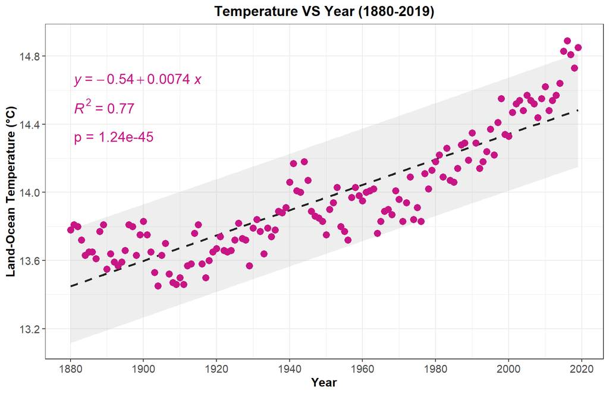

## By Intervals

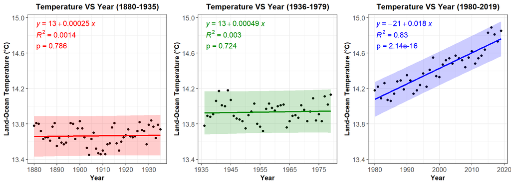

## Predicting Future Temperatures

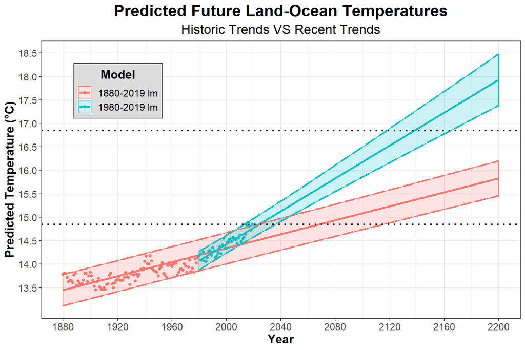

## Ranking Models By \(R^{2}\)

| Model | \(R^{2}\) | Time Period |
| --- | --- | --- |
| \(Population\) ~ \(Year\) | \(0.998\) | 1955-2017 |
| \(Concentrations: CO_{2}\) ~ \(N_{2}O\) | \(0.997\) | 1880-2016 |
| \(N_{2}O\ Concentration\) ~ \(Population\) | \(0.992\) | 1955-2017 |
| \(CO_{2}\ Concentration\) ~ \(Population\) | \(0.988\) | 1955-2017 |
| \(CO_{2}\ Emissions\) ~ \(Year\) | \(0.974\) | 1955-2017 |
| \(CO_{2}\ Concentration\) ~ \(CO_{2}\ Emissions\) | \(0.971\) | 1955-2017 |
| \(CO_{2}\ Emissions\) ~ \(Population\) | \(0.971\) | 1955-2017 |
| \(CH_{4}\ Concentration\) ~ \(Year\) | \(0.966\) | 1880-2018 |
| \(Emissions: CO_{2}\) ~ \(CH_{4}\) | \(0.934\) | 1970-2012 |
| \(N_{2}O\ Concentration\) ~ \(LandOceanTemp\) | \(0.912\) | 1880-2018 |
| \(CH_{4}\ Emissions\) ~ \(Year\) | \(0.911\) | 1970-2012 |

## Miscellaneous Models

| Model | \(R^{2}\) | Time Period |
| --- | --- | --- |
| \(Population\) ~ \(Year\) | \(0.998\) | 1955-2017 |
| \(LandOceanTemp\) ~ \(Population\) | \(0.871\) | 1955-2017 |
| \(LandOceanTemp(Recent)\) ~ \(Year\) | \(0.834\) | 1980-2019 |
| \(LandOceanTemp\) ~ \(Year\) | \(0.768\) | 1880-2019 |

## CO2 Models

| Model | \(R^{2}\) | Time Period |
| --- | --- | --- |
| \(CO_{2}\ Concentration\) ~ \(Population\) | \(0.988\) | 1955-2017 |
| \(CO_{2}\ Emissions\) ~ \(Year\) | \(0.974\) | 1955-2017 |
| \(CO_{2}\ Concentration\) ~ \(CO_{2}\ Emissions\) | \(0.971\) | 1955-2017 |
| \(CO_{2}\ Emissions\) ~ \(Population\) | \(0.971\) | 1955-2017 |
| \(CO_{2}\ Concentration\) ~ \(LandOceanTemp\) | \(0.885\) | 1880-2018 |
| \(CO_{2}\ Concentration\) ~ \(Year\) | \(0.855\) | 1880-2018 |
| \(CO_{2}\ Emissions\) ~ \(LandOceanTemp\) | \(0.837\) | 1955-2017 |

## CH4 Models

| Model | \(R^{2}\) | Time Period |
| --- | --- | --- |
| \(CH_{4}\ Concentration\) ~ \(Year\) | \(0.966\) | 1880-2018 |
| \(CH_{4}\ Emissions\) ~ \(Year\) | \(0.911\) | 1970-2012 |
| \(CH_{4}\ Emissions\) ~ \(Population\) | \(0.909\) | 1970-2012 |
| \(CH_{4}\ Concentration\) ~ \(Population\) | \(0.874\) | 1955-2017 |
| \(CH_{4}\ Concentration\) ~ \(LandOceanTemp\) | \(0.803\) | 1880-2018 |
| \(CH_{4}\ Emissions\) ~ \(LandOceanTemp\) | \(0.780\) | 1970-2012 |
| \(CH_{4}\ Concentration\) ~ \(CH_{4}\ Emissions\) | \(0.706\) | 1970-2012 |

## N2O Models

| Model | \(R^{2}\) | Time Period |
| --- | --- | --- |
| \(N_{2}O\ Concentration\) ~ \(Population\) | \(0.992\) | 1955-2017 |
| \(N_{2}O\ Concentration\) ~ \(LandOceanTemp\) | \(0.912\) | 1880-2018 |
| \(N_{2}O\ Concentration\) ~ \(Year\) | \(0.900\) | 1880-2016 |
| \(N_{2}O\ Emissions\) ~ \(Year\) | \(0.754\) | 1970-2012 |
| \(N_{2}O\ Emissions\) ~ \(Population\) | \(0.751\) | 1970-2012 |
| \(N_{2}O\ Emissions\) ~ \(LandOceanTemp\) | \(0.703\) | 1970-2012 |
| \(N_{2}O\ Concentration\) ~ \(N_{2}O\ Emissions\) | \(0.649\) | 1970-2012 |

## Concentration Models

| Concentrataion Models | \(R^{2}\) | Time Period |
| --- | --- | --- |
| \(CO_{2}\) ~ \(N_{2}O\) | \(0.997\) | 1880-2016 |
| \(CH_{4}\) ~ \(N_{2}O\) | \(0.907\) | 1880-2016 |
| \(CO_{2}\) ~ \(CH_{4}\) | \(0.859\) | 1880-2018 |

## Emissions Models

[output not shown]

## Discussion, Limitations, Suggestions, Conclusion

## Discussion

- **How have gas emissions, concentration, temperatures, and the population changed over time?**
- **Are gas emissions, concentrations, and the population related to temperature?**
- **Will global temperatures increase in the future? If so, by how much**
  - Recent trends predict temperature will increase by 2°C around the year 2150 and by 3°C by 2200
  - Overall trends since 1880 predict a 1°C increase by 2200

*Can Real Progress Be Made*

*If The Population Keeps*

*Increasing?*

## Limitations

- Correlations do not imply causations
- The chemistry involving GHGs was not analyzed

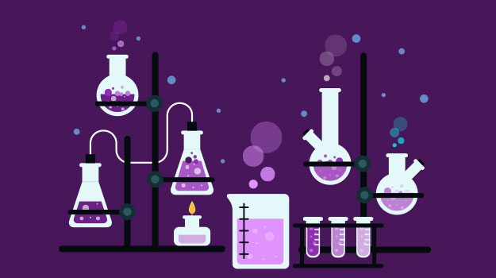

## Suggestions

- This study provides the statistical analysis that chemist can uses moving forward
- **Future Research**
  - Should consider the chemical background
  - Determine the best strategies to decrease CO2 emissions

## Conclusion

- Global Warming is a serious threat facilitated by GHGs.
- Steps should be implemented to reduce GHG emissions
- Based on the strengths of linear models, reducing CO2 emissions should be prioritized

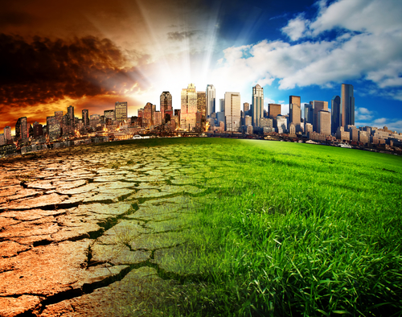

## References

- “Climate Change Indicators: Greenhouse Gases.” EPA, Environmental Protection Agency, 22 Feb. 2017, www.epa.gov/climate-indicators/greenhouse-gases.
- European Commission, Joint Research Centre (JRC)/Netherlands Environmental Assessment Agency (PBL). Emission Database for Global Atmospheric Research (EDGAR): http://edgar.jrc.ec.europa.eu/
- European Environment Agency (EEA) & Advanced Global Atmospheric Gases Experiment (AGAGE). https://www.eea.europa.eu/data-and-maps/data/external/agage-measurements.
- European Environment Agency (EEA) & National Oceanic and Atmospheric Administration (NOAA). https://www.eea.europa.eu/data-and-maps/data/external/agage-measurements.
- Global Carbon Project. (2019). CO2 Emissions. http://www.globalcarbonatlas.org/en/CO2-emissions
- Hannah Ritchie and Max Roser (2020) - “CO₂ and Greenhouse Gas Emissions”. Published online at OurWorldInData.org. https://ourworldindata.org/co2-and-other-greenhouse-gas-emissions’
- IPCC, 2013: Climate Change 2013: The Physical Science Basis. Contribution of Working Group I to the Fifth Assessment Report of the Intergovernmental Panel on Climate Change [Stocker, T.F., D. Qin, G.-K. Plattner, M. Tignor, S.K. Allen, J. Boschung, A. Nauels, Y. Xia, V. Bex and P.M. Midgley (eds.)]. Cambridge University Press, Cambridge, United Kingdom and New York, NY, USA.
- NOAA National Centers for Environmental information, Climate at a Glance: Global Time Series, published April 2020, retrieved on April 20, 2020 from https://www.ncdc.noaa.gov/cag/
- Triola, M. F. (2014) Elementary Stataistics (12th edition). Pearson Inc.